# DSSS2022 Machine Learning in R: Task List 05

Goran S. Milovanovic, DataKolektiv

# Regularized Multiple Linear Regression

You will need to install the `glmnet` package for this exercise: `install.packages("glmnet")`

```r
library(tidyverse)
library(glmnet)
library(car)
data_dir <- paste0(getwd(), "/_data/")
```

### Task 00

Read through carefully everything that follows. In the bottom of the Notebook you will find Task 01 and this is the only “real” task for you here (i.e. where you will need to write some code). Make sure that Google for each new R function in this Task List and learn how to use it.

The following vignette might prove to be useful here: [An Introduction to glmnet](https://glmnet.stanford.edu/articles/glmnet.html).

### Multiple Linear Regression with `glmnet`

We will use the `kc_house_data.csv` dataset. It is available on Kaggle: [Multiple Linear Regression: House Sales in King County, USA](https://www.kaggle.com/code/divan0/multiple-linear-regression/data). The task here is to predict the pricing of a property.

```r
data_set <- read.csv(paste0(data_dir, "kc_house_data.csv"),
                     header = TRUE,
                     check.names = FALSE,
                     stringsAsFactors = FALSE)
head(data_set)
```

|  | id | date | price | bedrooms | bathrooms | sqft_living | sqft_lot | floors | waterfront | view | condition | grade | sqft_above | sqft_basement | yr_built | yr_renovated | zipcode | lat | long | sqft_living15 | sqft_lot15 |
| --- | --- | --- | --- | --- | --- | --- | --- | --- | --- | --- | --- | --- | --- | --- | --- | --- | --- | --- | --- | --- | --- |
| 1 | 7129300520 | 20141013T000000 | 221900 | 3 | 1.00 | 1180 | 5650 | 1 | 0 | 0 | 3 | 7 | 1180 | 0 | 1955 | 0 | 98178 | 47.5112 | -122.257 | 1340 | 5650 |
| 2 | 6414100192 | 20141209T000000 | 538000 | 3 | 2.25 | 2570 | 7242 | 2 | 0 | 0 | 3 | 7 | 2170 | 400 | 1951 | 1991 | 98125 | 47.7210 | -122.319 | 1690 | 7639 |
| 3 | 5631500400 | 20150225T000000 | 180000 | 2 | 1.00 | 770 | 10000 | 1 | 0 | 0 | 3 | 6 | 770 | 0 | 1933 | 0 | 98028 | 47.7379 | -122.233 | 2720 | 8062 |
| 4 | 2487200875 | 20141209T000000 | 604000 | 4 | 3.00 | 1960 | 5000 | 1 | 0 | 0 | 5 | 7 | 1050 | 910 | 1965 | 0 | 98136 | 47.5208 | -122.393 | 1360 | 5000 |
| 5 | 1954400510 | 20150218T000000 | 510000 | 3 | 2.00 | 1680 | 8080 | 1 | 0 | 0 | 3 | 8 | 1680 | 0 | 1987 | 0 | 98074 | 47.6168 | -122.045 | 1800 | 7503 |
| 6 | 7237550310 | 20140512T000000 | 1225000 | 4 | 4.50 | 5420 | 101930 | 1 | 0 | 0 | 3 | 11 | 3890 | 1530 | 2001 | 0 | 98053 | 47.6561 | -122.005 | 4760 | 101930 |

Let’s inspect the data:

```r
glimpse(data_set)
```

```
Rows: 21,613
Columns: 21
$ id            <dbl> 7129300520, 6414100192, 5631500400, 2487200875, 1954400510, 7237550310, 1321400060, 2008000270, 2414600126, 3793500160, 173680…
$ date          <chr> "20141013T000000", "20141209T000000", "20150225T000000", "20141209T000000", "20150218T000000", "20140512T000000", "20140627T00…
$ price         <dbl> 221900, 538000, 180000, 604000, 510000, 1225000, 257500, 291850, 229500, 323000, 662500, 468000, 310000, 400000, 530000, 65000…
$ bedrooms      <int> 3, 3, 2, 4, 3, 4, 3, 3, 3, 3, 3, 2, 3, 3, 5, 4, 3, 4, 2, 3, 4, 3, 5, 2, 3, 3, 3, 3, 3, 4, 3, 2, 4, 3, 4, 3, 4, 4, 4, 4, 4, 4, …
$ bathrooms     <dbl> 1.00, 2.25, 1.00, 3.00, 2.00, 4.50, 2.25, 1.50, 1.00, 2.50, 2.50, 1.00, 1.00, 1.75, 2.00, 3.00, 2.00, 1.00, 1.00, 1.00, 1.75, …
$ sqft_living   <int> 1180, 2570, 770, 1960, 1680, 5420, 1715, 1060, 1780, 1890, 3560, 1160, 1430, 1370, 1810, 2950, 1890, 1600, 1200, 1250, 1620, 3…
$ sqft_lot      <int> 5650, 7242, 10000, 5000, 8080, 101930, 6819, 9711, 7470, 6560, 9796, 6000, 19901, 9680, 4850, 5000, 14040, 4300, 9850, 9774, 4…
$ floors        <dbl> 1.0, 2.0, 1.0, 1.0, 1.0, 1.0, 2.0, 1.0, 1.0, 2.0, 1.0, 1.0, 1.5, 1.0, 1.5, 2.0, 2.0, 1.5, 1.0, 1.0, 1.0, 1.0, 2.0, 1.0, 2.0, 1…
$ waterfront    <int> 0, 0, 0, 0, 0, 0, 0, 0, 0, 0, 0, 0, 0, 0, 0, 0, 0, 0, 0, 0, 0, 0, 0, 0, 0, 0, 0, 0, 0, 0, 0, 0, 0, 0, 0, 0, 0, 0, 0, 0, 0, 0, …
$ view          <int> 0, 0, 0, 0, 0, 0, 0, 0, 0, 0, 0, 0, 0, 0, 0, 3, 0, 0, 0, 0, 0, 4, 0, 0, 0, 0, 0, 0, 0, 0, 0, 0, 0, 0, 0, 0, 0, 0, 0, 0, 0, 0, …
$ condition     <int> 3, 3, 3, 5, 3, 3, 3, 3, 3, 3, 3, 4, 4, 4, 3, 3, 3, 4, 4, 4, 4, 3, 3, 3, 4, 5, 3, 5, 3, 3, 3, 3, 4, 4, 3, 3, 1, 4, 2, 3, 3, 3, …
$ grade         <int> 7, 7, 6, 7, 8, 11, 7, 7, 7, 7, 8, 7, 7, 7, 7, 9, 7, 7, 7, 7, 7, 9, 8, 7, 8, 6, 8, 8, 7, 8, 8, 7, 7, 8, 7, 8, 5, 8, 7, 8, 9, 8,…
$ sqft_above    <int> 1180, 2170, 770, 1050, 1680, 3890, 1715, 1060, 1050, 1890, 1860, 860, 1430, 1370, 1810, 1980, 1890, 1600, 1200, 1250, 860, 233…
$ sqft_basement <int> 0, 400, 0, 910, 0, 1530, 0, 0, 730, 0, 1700, 300, 0, 0, 0, 970, 0, 0, 0, 0, 760, 720, 0, 0, 0, 0, 700, 0, 730, 0, 0, 0, 820, 0…
$ yr_built      <int> 1955, 1951, 1933, 1965, 1987, 2001, 1995, 1963, 1960, 2003, 1965, 1942, 1927, 1977, 1900, 1979, 1994, 1916, 1921, 1969, 1947, …
$ yr_renovated  <int> 0, 1991, 0, 0, 0, 0, 0, 0, 0, 0, 0, 0, 0, 0, 0, 0, 0, 0, 0, 0, 0, 0, 0, 0, 0, 0, 0, 0, 0, 0, 0, 0, 0, 0, 0, 2002, 0, 0, 0, 0, …
$ zipcode       <int> 98178, 98125, 98028, 98136, 98074, 98053, 98003, 98198, 98146, 98038, 98007, 98115, 98028, 98074, 98107, 98126, 98019, 98103, …
$ lat           <dbl> 47.5112, 47.7210, 47.7379, 47.5208, 47.6168, 47.6561, 47.3097, 47.4095, 47.5123, 47.3684, 47.6007, 47.6900, 47.7558, 47.6127, …
$ long          <dbl> -122.257, -122.319, -122.233, -122.393, -122.045, -122.005, -122.327, -122.315, -122.337, -122.031, -122.145, -122.292, -122.2…
$ sqft_living15 <int> 1340, 1690, 2720, 1360, 1800, 4760, 2238, 1650, 1780, 2390, 2210, 1330, 1780, 1370, 1360, 2140, 1890, 1610, 1060, 1280, 1400, …
$ sqft_lot15    <int> 5650, 7639, 8062, 5000, 7503, 101930, 6819, 9711, 8113, 7570, 8925, 6000, 12697, 10208, 4850, 4000, 14018, 4300, 5095, 8850, 4…
```

For reasons of simplicity, we will keep only some variables in the dataset:

```r
model_set <- data_set %>%
  select(-all_of(c("id", "lat", "long", "date",
                   "zipcode", "yr_renovated", "waterfront",
                   "view", "sqft_basement")))
```

The correlations of predictors:

```r
cor_frame <- model_set %>%
  select(-price)
cor(cor_frame)
```

```
                bedrooms   bathrooms sqft_living     sqft_lot       floors    condition      grade sqft_above    yr_built sqft_living15   sqft_lot15
bedrooms      1.00000000  0.51588364  0.57667069  0.031703243  0.175428935  0.028472104  0.3569667  0.4776002  0.15417807    0.39163752  0.029244224
bathrooms     0.51588364  1.00000000  0.75466528  0.087739662  0.500653173 -0.124981933  0.6649825  0.6853425  0.50601944    0.56863429  0.087175361
sqft_living   0.57667069  0.75466528  1.00000000  0.172825661  0.353949290 -0.058752587  0.7627045  0.8765966  0.31804877    0.75642026  0.183285551
sqft_lot      0.03170324  0.08773966  0.17282566  1.000000000 -0.005200991 -0.008958250  0.1136211  0.1835123  0.05308037    0.14460817  0.718556752
floors        0.17542894  0.50065317  0.35394929 -0.005200991  1.000000000 -0.263767946  0.4581825  0.5238847  0.48931942    0.27988527 -0.011269187
condition     0.02847210 -0.12498193 -0.05875259 -0.008958250 -0.263767946  1.000000000 -0.1446737 -0.1582136 -0.36141656   -0.09282427 -0.003405523
grade         0.35696673  0.66498253  0.76270448  0.113621124  0.458182514 -0.144673671  1.0000000  0.7559229  0.44696320    0.71320209  0.119247897
sqft_above    0.47760016  0.68534248  0.87659660  0.183512281  0.523884710 -0.158213616  0.7559229  1.0000000  0.42389835    0.73187029  0.194049862
yr_built      0.15417807  0.50601944  0.31804877  0.053080367  0.489319425 -0.361416562  0.4469632  0.4238984  1.00000000    0.32622890  0.070957926
sqft_living15 0.39163752  0.56863429  0.75642026  0.144608174  0.279885265 -0.092824268  0.7132021  0.7318703  0.32622890    1.00000000  0.183191749
sqft_lot15    0.02924422  0.08717536  0.18328555  0.718556752 -0.011269187 -0.003405523  0.1192479  0.1940499  0.07095793    0.18319175  1.000000000
```

Perform a multiple linear regression with `lm()`:

```r
mlr <- lm(price ~ .,
          data = model_set)
summary(mlr)
```

```
Call:
lm(formula = price ~ ., data = model_set)

Residuals:
     Min       1Q   Median       3Q      Max
-1269678  -115576   -12141    89488  4485685

Coefficients:
                Estimate Std. Error t value Pr(>|t|)
(Intercept)    6.933e+06  1.359e+05  51.002  < 2e-16 ***
bedrooms      -4.936e+04  2.109e+03 -23.406  < 2e-16 ***
bathrooms      5.010e+04  3.626e+03  13.817  < 2e-16 ***
sqft_living    1.952e+02  4.812e+00  40.552  < 2e-16 ***
sqft_lot       1.111e-02  5.370e-02   0.207    0.836
floors         3.348e+04  3.957e+03   8.461  < 2e-16 ***
condition      1.898e+04  2.580e+03   7.356 1.97e-13 ***
grade          1.246e+05  2.347e+03  53.099  < 2e-16 ***
sqft_above    -2.866e+01  4.678e+00  -6.128 9.06e-10 ***
yr_built      -3.968e+03  6.977e+01 -56.875  < 2e-16 ***
sqft_living15  3.627e+01  3.735e+00   9.709  < 2e-16 ***
sqft_lot15    -5.066e-01  8.207e-02  -6.172 6.86e-10 ***
---
Signif. codes:  0 ‘***’ 0.001 ‘**’ 0.01 ‘*’ 0.05 ‘.’ 0.1 ‘ ’ 1

Residual standard error: 226400 on 21601 degrees of freedom
Multiple R-squared:  0.6199,    Adjusted R-squared:  0.6197
F-statistic:  3202 on 11 and 21601 DF,  p-value: < 2.2e-16
```

Check the Variance Inflation Factors:

```r
car::vif(mlr)
```

```
     bedrooms     bathrooms   sqft_living      sqft_lot        floors     condition         grade    sqft_above      yr_built sqft_living15
     1.621833      3.287936      8.236167      2.085978      1.925165      1.188449      3.208241      6.325912      1.770933      2.763124
   sqft_lot15
     2.117307
```

Some familiarity with the `glmnet` terminology is needed here too:

> “The elastic net penalty is controlled by $\alpha$, and bridges the gap between lasso regression ($\alpha=1$, the default) and ridge regression ($\alpha=0$). The tuning parameter $\lambda$ controls the overall strength of the penalty.” From: [An Introduction to glmnet](https://glmnet.stanford.edu/articles/glmnet.html)

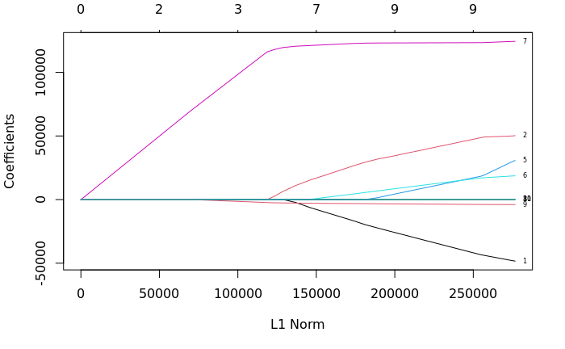

```r
X <- model_set %>% select(-price)
y <- model_set$price
glmnet_mlr <- glmnet(x = X, y = y,
                     alpha = 1,
                     family = "gaussian")
plot(glmnet_mlr, label = TRUE)
```

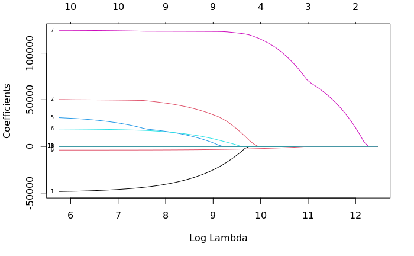

```r
plot(glmnet_mlr, label = TRUE, xvar = "lambda")
```

How to interpret the plot above?

Once again, the $L1$ norm is the $LASSO$ regression penalization:

$$\lambda*(|\beta_1|+|\beta_2|+...+|\beta_k|)$$

where $k$ is how many predictors we have in the model; on the other hand, the $L2$ norm (the Ridge Regression norm):

$$\lambda*(\beta_1^2+\beta_2^2+...+\beta_k^2)$$
We can obtain the range of $\lambda$ values that were tried out in model optimization:

```r
glmnet_mlr$lambda
```

```
 [1] 257730.1988 234834.1583 213972.1389 194963.4438 177643.4288 161862.0762 147482.6955 134380.7393 122442.7248 111565.2506 101654.1012  92623.4310
[13]  84395.0207  76897.5996  70066.2288  63841.7382  58170.2141  53002.5326  48293.9337  44003.6337  40094.4722  36532.5898  33287.1352  30329.9978
[25]  27635.5644  25180.4971  22943.5311  20905.2910  19048.1226  17355.9399  15814.0860  14409.2062  13129.1320  11962.7761  10900.0361   9931.7069
[37]   9049.4014   8245.4776   7512.9721   6845.5403   6237.4014   5683.2878   5178.4002   4718.3654   4299.1988   3917.2699   3569.2704   3252.1863
[49]   2963.2710   2700.0222   2460.1596   2241.6058   2042.4677   1861.0205   1695.6926   1545.0520   1407.7938   1282.7293   1168.7751   1064.9444
[61]    970.3377    884.1355    805.5914    734.0249    668.8161    609.4003    555.2629    505.9349    460.9890    420.0360    382.7212    348.7213
[73]    317.7418
```

And the obtain the deviance (i.e. $-2LL$) of each model:

```r
deviance(glmnet_mlr)
```

```
 [1] 2.912917e+15 2.669170e+15 2.466808e+15 2.287896e+15 2.129714e+15 1.998281e+15 1.889225e+15 1.798685e+15 1.723517e+15 1.661112e+15 1.609302e+15
[12] 1.566253e+15 1.530548e+15 1.500905e+15 1.476295e+15 1.455864e+15 1.427891e+15 1.381856e+15 1.343633e+15 1.311900e+15 1.285554e+15 1.263672e+15
[23] 1.245514e+15 1.230288e+15 1.217476e+15 1.206784e+15 1.197916e+15 1.190553e+15 1.183439e+15 1.176913e+15 1.168954e+15 1.160293e+15 1.152799e+15
[34] 1.146566e+15 1.140998e+15 1.135965e+15 1.131500e+15 1.127738e+15 1.124592e+15 1.121980e+15 1.119819e+15 1.118018e+15 1.116522e+15 1.115281e+15
[45] 1.114257e+15 1.113400e+15 1.112689e+15 1.112098e+15 1.111615e+15 1.111207e+15 1.110868e+15 1.110587e+15 1.110353e+15 1.109934e+15 1.109475e+15
[56] 1.109111e+15 1.108803e+15 1.108555e+15 1.108342e+15 1.108164e+15 1.108022e+15 1.107899e+15 1.107796e+15 1.107715e+15 1.107644e+15 1.107585e+15
[67] 1.107539e+15 1.107498e+15 1.107463e+15 1.107437e+15 1.107415e+15 1.107395e+15 1.107378e+15
```

So the best model - *without cross-validation across $\lambda$* - would be:

```r
w_best <- which.min(deviance(glmnet_mlr))
print(w_best)
```

```
[1] 73
```

And we can find out at what $\lambda$ value was this model found:

```r
best_lambda <- glmnet_mlr$lambda[w_best]
print(best_lambda)
```

```
[1] 317.7418
```

```r
X <- model_set %>% select(-price)
y <- model_set$price
glmnet_mlr_best <- glmnet(x = X, y = y,
                          alpha = 1,
                          lambda = best_lambda,
                          family = "gaussian")
```

And the coefficients in this model would be:

```r
coeffs <- as.data.frame(as.matrix(coefficients(glmnet_mlr_best)))
print(coeffs)
```

|  | s0 |
| --- | --- |
| (Intercept) | 6.900333e+06 |
| bedrooms | -4.839119e+04 |
| bathrooms | 4.973621e+04 |
| sqft_living | 1.918553e+02 |
| sqft_lot | 0.000000e+00 |
| floors | 3.107282e+04 |
| condition | 1.868948e+04 |
| grade | 1.244923e+05 |
| sqft_above | -2.406316e+01 |
| yr_built | -3.949898e+03 |

[output cut: 2 more lines]

**Look ahead.** Cross-validation across $\lambda$:

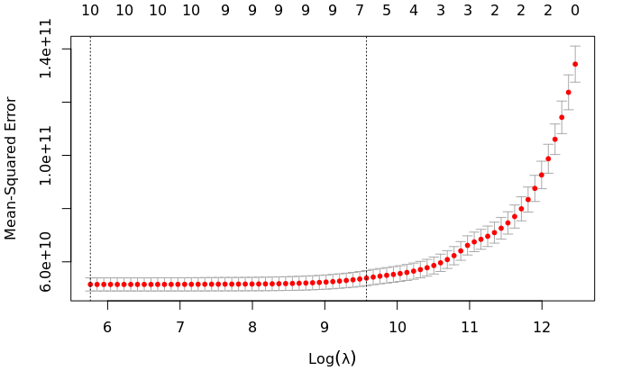

```r
glmnet_mlr_cv <- cv.glmnet(x = as.matrix(X), y = y,
                           alpha = 1,
                           family = "gaussian")
plot(glmnet_mlr_cv)
```

The best performing value of $\lambda$ in cross-validation is found at:

```r
glmnet_mlr_cv$lambda.min
```

```
[1] 317.7418
```

Then:

```r
glmnet_mlr_best <- glmnet(x = X, y = y,
                          alpha = 1,
                          lambda = glmnet_mlr_cv$lambda.min,
                          family = "gaussian")
coeffs <- as.data.frame(as.matrix(coefficients(glmnet_mlr_best)))
print(coeffs)
```

|  | s0 |
| --- | --- |
| (Intercept) | 6.900333e+06 |
| bedrooms | -4.839119e+04 |
| bathrooms | 4.973621e+04 |
| sqft_living | 1.918553e+02 |
| sqft_lot | 0.000000e+00 |
| floors | 3.107282e+04 |
| condition | 1.868948e+04 |
| grade | 1.244923e+05 |
| sqft_above | -2.406316e+01 |
| yr_built | -3.949898e+03 |

[output cut: 2 more lines]

The $R^2$ for this model is:

```r
predictions <- predict(glmnet_mlr_cv,
                       newx = as.matrix(X),
                       s = glmnet_mlr_cv$lambda.min)
r2 <- as.numeric(cor(predictions, y)^2)
print(r2)
```

```
[1] 0.6198425
```

**Data Science Summer School 2022**  
**Machine Learning in R**  
DataKolektiv, Belgrade, June 2022.